# Miembros Ecoinformática AEET

**Miembros del [grupo de Ecoinformática](http://www.aeet.org/EcoInformatica_383_p.htm) de la [Asociación Española de Ecología Terrestre (AEET)](http://www.aeet.org/).**

**Para darte de alta rellena tus datos [aquí](https://docs.google.com/forms/d/e/1FAIpQLScCIlXvN2LtOkj1MNFPK-UzTfkK8jg5ZMXT0OgjyUUJdndo2Q/viewform?c=0&w=1). Si quieres actualizar o corregir un error en los datos por favor abre un ‘issue’ [en el repo](https://github.com/ecoinfAEET/MembersInfo) o escribe a ecoinf.aeet@gmail.com.**

### Aitor Ameztegui

[figure not shown]

### Contacto

Investigador Postdoctoral

CREAF - CTFC

ameztegui@gmail.com

Web / [Twitter](https://twitter.com/multivac42) / [GitHub](https://github.com/ameztegui)

### Líneas de investigación

Mis investigaciones pretenden mejorar el conocimiento sobre las respuestas de los bosques a los diversos cambios ambientales y determinar el papel de la gestión forestal en la dinámica futura de los ecosistemas forestales.Mi trabajo actual se centra en el estudio de los mecanismos y factores que rigen la dinámica forestal y la coexistencia de las especies, con especial énfasis en la regeneración y la resiliencia del bosque frente a perturbaciones, tanto naturales como antrópicas. También me interesa particularmente el estudio de los patrones espaciales, causas y consecuencias de la expansión del bosque en áreas de montaña.

*Keywords*: dinámica forestal, resiliencia, modelización, gestión forestal, cambio climático, expansión del bosque

### Intereses

cursos, seminarios, estadística, Rstats, modelización

### Alfonso Garmendia

### Contacto

Investigador en plantilla

Universitat Politècnica de València

algarsal@upvnet.upv.es

Web / [Twitter](https://twitter.com/) / [GitHub](https://github.com/algarsal)

### Líneas de investigación

Mecanismos de hibridación y poliploidización en la especiación de Centaurea. Trabajos de mejora de tomate y de técnicas agrárias en cítricos. Gestión forestal para la conservación de pícidos como especies paraguas. Efecto de las perturbaciones en los cambios de estrategias de reproducción de plantas.

*Keywords*: Centaurea, Hibridación, Tomate, cítricos, Ploidia, Pícidae, Perturbaciones, …

### Intereses

Optimizar formas de trabajo. Aprender.

### Ana I. García-Cervigón

### Contacto

Investigador Postdoctoral

Centro de Ecología Aplicada “Baeta Neves” - Universidad de Lisboa Universidad de Cádiz (a partir de abril)

ana.gcervigon.morales@gmail.com

Web / [Twitter](https://twitter.com/) / [GitHub](https://github.com/anagc)

### Líneas de investigación

Tesis doctoral sobre interacciones entre plantas en alta montaña mediterránea, con Juniperus sabina como planta nodriza y usando la dendro para incluir el tiempo en el análisis de las interacciones. Postdoc en dendrocronología tropical con especies de bosque seco del sur de Ecuador. Postdoc en dispersión de semillas en Doñana en el marco de la “seed dispersal effectiveness”.

*Keywords*: Ecología vegetal, interacciones planta-planta, dendrocronología, anatomía cuantitativa de la madera, dispersión de semillas

### Intereses

Mejorar mis habilidades de programación para poder hacer ciencia reproducible. Aprender sobre análisis estadísticos concretos. Compartir información al respecto.

### Antonio Jesús Pérez Luque

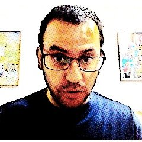

### Contacto

Investigador Predoctoral

Laboratorio de Ecología, Instituto Investigación Sistema Tierra Andalucía - Universidad de Granada

ajpelu@gmail.com

Web / [Twitter](https://twitter.com/ajpelu) / [GitHub](https://github.com/ajpelu)

### Líneas de investigación

Spatio-temporal dynamics of forests in Mediterranean ountains. Data Analysis and Ecoinformatics. Design of Environmental Information Systems.

*Keywords*: global change; forest ecology; high-mountain; ecoinformatics; remote sensing;

### Intereses

Análisis de datos R; Reproducibilidad; Metadatos y Gestión de Información; Control de versiones

### Carlos Lara Romero

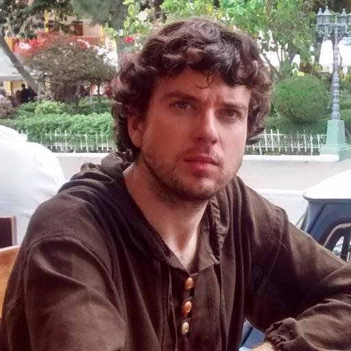

### Contacto

Investigador Postdoctoral

Institudo Meditarráneo de Estudios Avanzados (IMEDEA). CSIC-UIB

carlos.lara.romero@gmail.com

Web / [Twitter](https://twitter.com/carlos_lara0) / [GitHub](https://github.com/)

### Líneas de investigación

Estoy interesado en la aplicación e integración de herramientas estadísticas en el campo de la ecología de poblaciones y las interacciones planta-animal. Algunas de estas técnicas son análisis de redes, técnicas de patrones de puntos, kernels de dispersión y modelos lineales mixtos.

*Keywords*: Ecological networks Local adaptation Spatial ecology

### Intereses

Compartir conocimientos sobre técnicas estadísticas y lenguajes de programación. Colaborar en la difusión y divulgación de nuevas técnicas estadísticas.

### Diego Nieto Lugilde

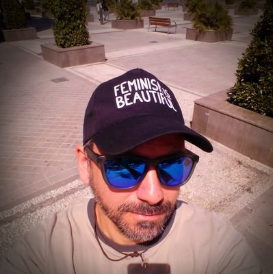

### Contacto

Profesor Contratado Doctor

Departamento de Botánica, Ecología y Fisiología Vegetal. Universidad de Córdoba

dnietolugilde@gmail.com

Web / [Twitter](https://twitter.com/dnietolugilde) / [GitHub](https://github.com/dinilu)

### Líneas de investigación

Mi investigación se centra en estudiar la respuesta de las especies vegetales, tanto de forma aislada como conjunta (vegetación), a los cambios ambientales en el pasado (desde el último máximo glaciar, ~21000 años BP). Para ello estudio los patrones biogeográficos y sus cambios a lo largo largos periodos de tiempo utilizando un enfoque macroecológico y herramientas ecoinformáticas.

*Keywords*: Paleoecología, Macroecología, Biogeografía, Cambio Climático, Vegetación

### Intereses

Intercambio de ideas e información, establecer redes de potenciales colaboradores, etc

### Felipe Bravo Oviedo

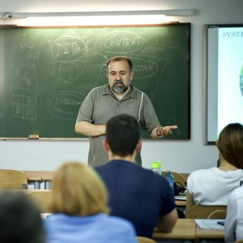

### Contacto

Investigador en plantilla

iuFOR, Instituto de Investigación en Gestión Forestal Sostenible, Universidad de Valladolid (Campus de Palencia)

fbravo@pvs.uva.es

Web / [Twitter](https://twitter.com/fbravo_SFM) / [GitHub](https://github.com/)

### Líneas de investigación

Selvicultura cuantitativa Dinámica de sistemas forestales (regeneración, crecimiento, mortalidad,..) Desarrollo de Sistemas de apoyo a la gestión (DSS, decission support system): www.simanfor.es

*Keywords*: sistemas forestales, desarrollo de software, crecimiento y producción, dinámica

### Intereses

Ampliar la red de colaboraciones (científicas, docentes o de transferencia ) y explorar nuevas ideas a partir de ella.

### Francisco Rodriguez-Sanchez

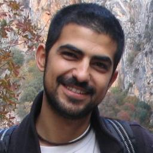

### Contacto

Investigador Postdoctoral

Estación Biológica de Doñana (CSIC)

frodriguez.work@gmail.com

[Web](http://bit.ly/frod_san) / [Twitter](https://twitter.com/frod_san) / [GitHub](https://github.com/Pakillo)

### Líneas de investigación

Mi línea principal de investigación aborda las consecuencias de los cambios climáticos en la biodiversidad, particularmente en la demografía y distribución de especies y la ecología de comunidades forestales a múltiples escalas: desde años/décadas a millones de años, y desde parcelas de campo a escala global. Estoy muy interesado en el desarrollo y aplicación de nuevas aproximaciones estadísticas para tratar de resolver cuestiones ecológicas y biogeográficas.

*Keywords*: forest dynamics, species range dynamics, climate change, community ecology, species distribution modelling, reproducible science.

### Intereses

- Programming (mostly R) and computational reproducible workflows
- Statistics (with Bayesian focus)
- Species distribution modelling
- Best practices in training the next generation of ecologists/ecoinformatics (i.e. teaching)

### Fulgencio Lisón Gil

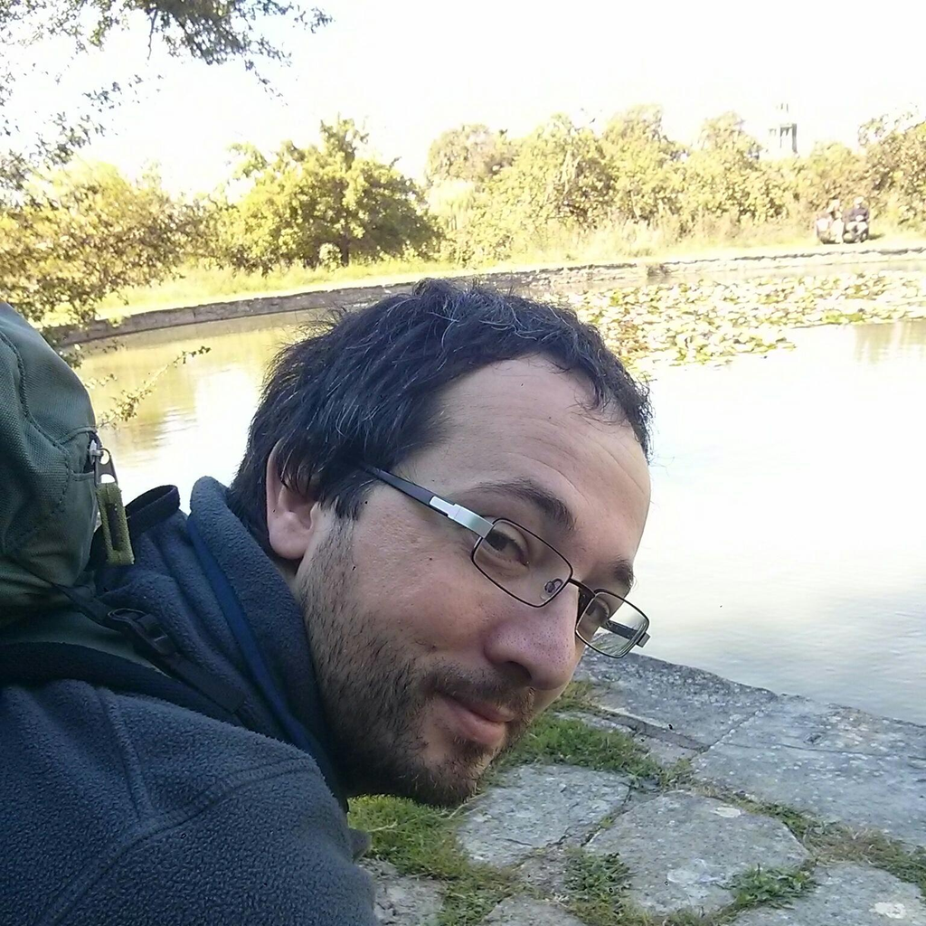

### Contacto

Investigador Postdoctoral

Universidad de La Frontera (Chile)

fulgencio.lison@ufrontera.cl

[Web](https://sites.google.com/site/fulgenciolison/) / [Twitter](https://twitter.com/FulgenLison) / [GitHub](https://github.com/)

### Líneas de investigación

Mi investigación está centrada en ecología de mamíferos, especialmente murciélagos. Mis lineas de investigación abarcan todos los aspectos de la ecología de murciélagos: autoecología, morfología, llamadas de ecolocación, biogeografía, filogenía y conservación

*Keywords*: murciélagos; mamíferos; ecología animal; conservación; áreas protegidas

### Intereses

Aprendizaje de R; Modelización; Ciencia libre

### Hugo Saiz

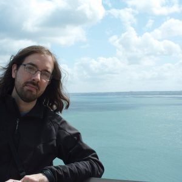

### Contacto

Investigador Postdoctoral

Departamento de Biología y Geología, Física y Química Inorgánica, Universidad Rey Juan Carlos

saizhugo@gmail.com

Web / [Twitter](https://twitter.com/HugoSaizB) / [GitHub](https://github.com/saizhugo)

### Líneas de investigación

Trabajo en los procesos de ensamblaje de las comunidades de plantas usando principalmente el analisis de redes aplicado al patrón espacial. Hasta ahora me he centrado en la identificación de patrones generales y ahora estoy tratando de identificar los mecanismos detrás de esos patrones

*Keywords*: Ecología de comunidades, Patrón espacial, Redes ecológicas, Modelos nulos

### Intereses

Creo que este grupo es una buena oportunidad para intercambiar ideas, sugerencias, consultas etc sobre este tema cada vez más complejo del ‘do it yourself’ analítico

### Ignasi Bartomeus

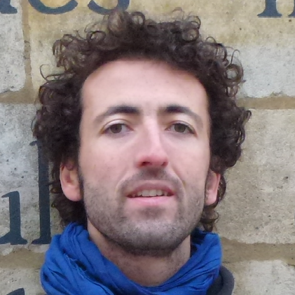

### Contacto

Ramón y Cajal

Estación Biológica de Doñana (EBD-CSIC)

nacho.bartomeus@gmail.com

Web / [Twitter](https://twitter.com/ibartomeus) / [GitHub](https://github.com/ibartomeus)

### Líneas de investigación

I am broadly interested in understanding how global change drivers impact community structure and composition, and how those impacts translate to the ecosystem functioning. I like to work with plant-pollinator communities because they show complex responses to land use change, climate warming or biological invasions, and encapsulate a critical ecosystem function, pollination.

*Keywords*: interacciones planta-animal, pollinización, abejas, biodiversidad, funcionamiento del ecosistema.

### Intereses

Abogar por la ciencia abierta y reproducible. Compartir conocimiento sobre ecología cuantitativa.

### Irene Mendoza

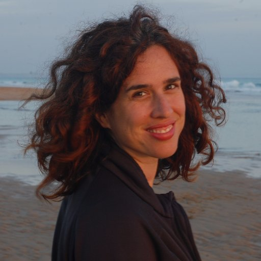

### Contacto

Investigador Postdoctoral

Universidade Estadual Paulista (Brasil)

irene.mendoza.sagrera@gmail.com

Web / [Twitter](https://twitter.com/phenogirl) / [GitHub](https://github.com/iremendoza)

### Líneas de investigación

I am an Ecologist intrigued in understanding how organisms and ecological interactions respond to global change, and using this knowledge to forecast future changes of ecosystems to human impacts. From all the ecological interactions, seed dispersal has always kept my interest given the deep consequences that it has for biodiversity, spatial distribution, and community dynamics. Thinking on what and how frugivore animals were dispersing led me to start asking about plant phenology, as the availability of resources (i.e. fruit) is critical for understanding dispersal patterns.

*Keywords*: phenology, climate change, plant-animal interactions, frugivory, seed dispersal

### Intereses

Improve my skills in version control of codes, R programming, and big data management. Networking with colleagues with similar interests. Help to improve ecological science in Spain in general, and large use of statistics and big data applied to Ecology in particular.

### Iris C.G.

### Contacto

Trabajador independiente

Trabajador independiente

iriscallejagomez@yahoo.es

Web / [Twitter](https://twitter.com/) / [GitHub](https://github.com/)

### Líneas de investigación

Fototrampeo, Ecología de Carreteras

*Keywords*: Ecología, Servicios Ecosistémicos, Sistema de Información Geográfica

### Intereses

Actualización software y aplicaciones para ecoinformática

### Jaime Uria-Diez

### Contacto

Investigador Postdoctoral

Swedish University of Agricultural Sciences SLU Faculty of Forest Sciences Department of Forest Resource Management Section of Mathematical Statistics Applied to Forest Sciences

jaime.uria.diez@slu.se

Web / [Twitter](https://twitter.com/) / [GitHub](https://github.com/)

### Líneas de investigación

I am a plant ecologist which uses spatial statistical approaches to disentangle how biotic and abiotic factors determine spatio-temporal pattern in plant species. My actual post-doctoral project focus in the study of how tree crown moves in response to intra and inter species competition. I like modelling and applying different (new) statistical tools/ techniques to spatial data, being also very interested in LIDAR information.

*Keywords*: Spatio-temporal point pattern analysis Population and community ecology Forest ecology Stream ecology Crown asymetry (Circular statistics)

### Intereses

Compartir y aprender nuevas técnicas de análisis espaciales. Aplicarlo a circular statistics. Como compartir script y que repositorios usar. RMarkDown

### Javier Martínez López

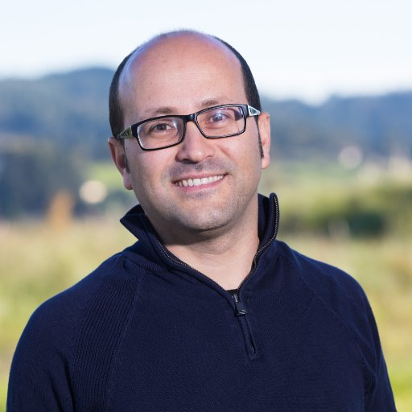

### Contacto

Investigador Postdoctoral

BC3-Basque Centre for Climate Change

javier.martinez@bc3research.org

Web / [Twitter](https://twitter.com/javi_marlop) / [GitHub](https://github.com/javimarlop)

### Líneas de investigación

My research interests, in a broad sense, are landscape ecology, remote sensing and ecosystem modeling. Currently, my research focuses on developing open source interoperable socio-ecological spatio-dynamic models and web services in relation to terrestrial, freshwater and marine ecosystems and their services.

*Keywords*: ecosystem services, ecological modelling, remote sensing

### Intereses

ecosystem services, ecological modelling, remote sensing

### Jose Oteros

### Contacto

Investigador Postdoctoral

Technical University of Munich

oterosjose@gmail.com

[Web](https://scholar.google.com/citations?hl=es&user=9I35R3kAAAAJ&view_op=list_works&gmla=AJsN-F4uxtH7jGBoEI78Q3CKAY3OR3wgr733TKXWzCPXp0BBntT0iy5xiopz51YC8d2v9WRwIFKeRJZvOo8qenmPhr9Xh_5KdZoFPh1wAZZ8jgbSrzV_EfY) / [Twitter](https://twitter.com/) / [GitHub](https://github.com/)

### Líneas de investigación

Coordinador de la red Bávara de Aerobiología, primera red de muestreo automático de polen de la historia. Modelos de dispersión. Geo-estadística. Estadítica. Programación. Botánica. Aerobiología.

*Keywords*: Aerobiology, Microecology, plants ecology, phenology

### Intereses

R, Phyton, Automatización de procesos, Bioestadística

### Juan J. Martínez Quesada

[figure not shown]

### Contacto

Investigador en plantilla

- CEO in TechInCrop
- Asistente Honorario Dpto. Biología Vegetal y Ecología. Área Fisiología Vegetal. Universidad de Sevilla

jjmartinez@techincrop.com

Web / [Twitter](https://twitter.com/TechInCrop) / [GitHub](https://github.com/jjmartique)

### Líneas de investigación

Real-time agro-systems monitoring, and modeling of agricultural systems. Reduction of inputs, and efficiency in the use of resources, trials and tracing. Transfer of results.

*Keywords*: Ecophysiology, Remote Sensing, Crop Modelling, AgTech, Decision Support Systems.

### Intereses

python, reproducible science, modelling, Remote Sensing.

### Maria Begoña Garcia

[figure not shown]

### Contacto

Investigador en plantilla

CSIC

mariab@ipe.csic.es

Web / [Twitter](https://twitter.com/mariaborderea) / [GitHub](https://github.com/)

### Líneas de investigación

Dinámica de la biodiversidad, especialmente en montaña, tanto a nivel de hábitat como de poblaciones de especies. Evolución de life history mediante el análisis de la variación espacio-temporal de tasas vitales en amplias gradientes ecológicos. Efecto de las interacciones ecológicas en la dinámica de las poblaciones

*Keywords*: Biodiversidad, conservación, ciencia ciudadana, demografía, interacciones ecológicas, plantas

### Intereses

Estar (un poco) al dia

### Marta Rueda

[figure not shown]

### Contacto

Investigador Postdoctoral

Estación Biológica de Doñana (EBD-CSIC)

mrueda.eco@gmail.com

Web / [Twitter](https://twitter.com/mrueda_eco) / [GitHub](https://github.com/)

### Líneas de investigación

Procesos ecológicos y evolutivos que determinan la distribución y riqueza de especies a diferentes escalas.

*Keywords*: Biogeografía, macroecología, ecología evolutiva, fragmentación y perdida hábitat, biología conservación

### Intereses

Estar en contacto y colaborar con investigadores y técnicos en el campo de la ecoinformatica, compartir mis conocimientos en este campo y aprender nuevos conocimientos y técnicas.

### Martina Sánchez-Pinillos

### Contacto

Investigador Predoctoral

Centro Tecnológico Forestal de Cataluña

martina.sanchez.pinillos@gmail.com

Web / [Twitter](https://twitter.com/) / [GitHub](https://github.com/)

### Líneas de investigación

Evaluar la capacidad de persistencia (resiliencia, resistencia) de los sistemas forestales ante perturbaciones naturales a través de los rasgos de respuesta de las especies que los constituyen. Caracterizar las dinámicas forestales post-perturbación a medio y largo plazo y evaluar el papel que los factores ambientales y socioeconómicos pueden tener en dichas dinámicas. Evaluar las interacciones y evolución de bosques mixtos mediterráneos tras la ocurrencia de grandes incendios forestales.

*Keywords*: Dinámica forestal, perturbaciones, resiliencia, resistencia, rasgos funcionales

### Intereses

Talleres, estadística, R packages, tutoriales

### Nuria Pistón Caballero

### Contacto

Investigador Postdoctoral

Universidad Federal de Río de Janeiro

nuriapiston@gmail.com

Web / [Twitter](https://twitter.com/) / [GitHub](https://github.com/)

### Líneas de investigación

Mis intereses se centran en la comprensión de los procesos que generan y mantienen la diversidad de las características funcionales y la diversidad vegetal en la naturaleza. En términos generales, me interesa el estudio de los mecanismos de coexistencia de especies y cómo estas responderán al cambio climático, el estudio de los filtros abióticos y bióticos que estructuran las comunidades de plantas, y las interacciones planta-planta y planta suelo.

*Keywords*: community assembly, functional traits, intraspecific variability, plant fitness, plant interactions, species coexistence.

### Intereses

Intercambiar ideas, consultas, crear una red que favorezca la colaboración.

### Oscar Godoy

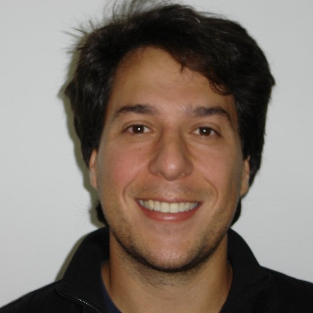

### Contacto

Investigador Postdoctoral

Instituto de Recursos Naturales y Agrobiología de Sevilla (IRNAS-CSIC)

41012 Sevilla (España)

ogodoy.re@gmail.com

Web / [Twitter](https://twitter.com/Eco_Godoy) / [GitHub](https://github.com/oscargodoy)

### Líneas de investigación

Soy ecólogo de comunidades. Me centro en como la interacción entre especies modula la biodiversidad. Me centro en interacción entre planta-planta aunque también estoy empezando a investigar interacciones entre planta-animal y animal-animal.

*Keywords*: Coexistencia, interacción entre especies, inventarios forestales, ecología de comunidades, bosques, praderas

### Intereses

Avanzar en conocimiento

1. Modelización Bayesiana para estimar fuerza de interacción entre especies.
2. Ciencia reproducible.
3. Representación de gráficos en R.
4. Métodos de clustering

### Paloma Ruiz benito

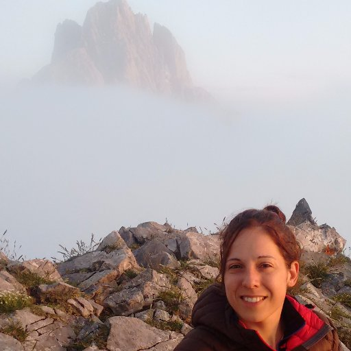

### Contacto

Investigador Postdoctoral

Forest Ecology and Restoration Group, Universidad de Alcalá

palomaruizbenito@gmail.com

[Web](https://palomaruizbenito.wordpress.com/) / [Twitter](https://twitter.com/_pRb_) / [GitHub](https://github.com/ruizbp)

### Líneas de investigación

I am a forest ecologist particularly interested in better understand the interactive effects of climate and land use change on forest functioning. My research seeks to study the mechanisms linking global environmental change, forest structure and dynamics and functional biogeography. My approach is strongly focus in the use of adequate modelling techniques and complex data around the world -e.g. from large-scale forest inventories to field-work data-.

*Keywords*: Climate change, diversity, forest dynamics, forest functioning, functional biogeography, land use change

### Intereses

big data, reproductible science, collaboration

### Rafael Poyatos

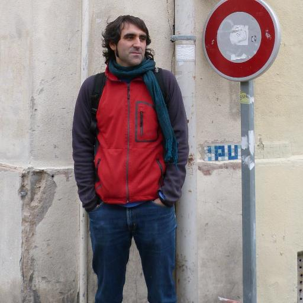

### Contacto

Investigador Postdoctoral

CREAF

r.poyatos@creaf.uab.es

[Web](http://www.creaf.cat/es/personal/rafael-poyatos-lopez) / [Twitter](https://twitter.com/RafaPoyatos) / [GitHub](https://github.com/rafapoyatos)

### Líneas de investigación

Soy ecofisiólogo vegetal e investigo cómo los factores ambientals interaccionan con la vegetación en el control de los flujos de agua y carbono en el ecosistema. Estudio la economía hídrica y del carbono en plantas bajo condiciones de sequía.

*Keywords*: ecofisiología vegetal, ecohidrología, ecología forestal, ecología funcional, flujo de savia, sequí

### Intereses

1. Estar al día de los recursos ecoinformáticos disponibles (código, fuentes de datos, buenas prácticas en la gestión de datos). 2) Compartir experiencias ecoinformáticas con la comunidad.

### Xavier Rotllan Puig

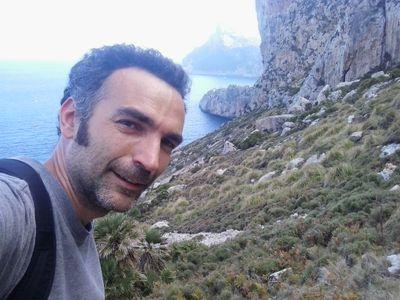

### Contacto

Técnico

Freelance

xafi.rp@gmail.com

Web / [Twitter](https://twitter.com/xavi_rp) / [GitHub](https://github.com/xavi-rp)

### Líneas de investigación

Ecología de plantas endémicas y/o amenazadas (sobretodo de Baleares).  
Modelos de distribución de especies. Desagregación de datos espaciales (impactos de la agricultura sobre el medio ambiente).

*Keywords*: Ecología plantas Interacciones planta-animal (polinización, dispersion semillas) Modelos distribución especies Análisis datos espaciales

### Intereses

Desarrollo modelos distribución especies con pocas presencias (sobretodo). Análisis de datos espaciales